# Lab Notebook

Sam Stockman, Annie Gray, Jack Simons

21/01/2021

# Introduction

The aim of this document is to outline how the functions and data in the package `tennis.wta` were used to produce the results in our report.

Let us begin by loading the package.

Now we read in the .csv data found within the package. Each file contains a year of tennis matches from the WTA tour and we have years 2000-2019.

```r
path_allfiles <- system.file("extdata", package = "tennis.wta")
file_list = list.files(path_allfiles)
#variables is the list of which columns we will be using
variables <- c('tourney_date','surface', 'winner_id', 'loser_id', 'winner_age', 'loser_age')
my_data <- load_data(file_list, variables)
```

Each row in our data, contains information about a single tennis match from the WTA tour beginning in the year 2000. It contains the date of the tournament in which the match was played, the surface the match was played on, then the identification and age of the winner and loser.

```r
head(my_data)
```

```
##   tourney_date surface winner_id loser_id winner_age loser_age
## 1   2000-01-03    Hard    200086   200008   24.75838  18.93224
## 2   2000-01-03    Hard    200060   200732   22.51061  21.11431
## 3   2000-01-03    Hard    200109   200036   20.86516  26.83094
## 4   2000-01-03    Hard    200049   200054   27.71526  22.45585
## 5   2000-01-03    Hard    200094   200027   26.69131  20.84326
## 6   2000-01-03    Hard    200093   200121   21.77139  22.95688
```

# Bradley-Terry Model

We shall first seek to fit a Bradley-Terry model to our data, to try and predict the outcome of the matches in 2019.

We begin by splitting the data into a testing and training set

```r
train_data <- my_data %>% filter(tourney_date < "2019-01-01")
test_data <- my_data %>% filter(tourney_date > "2019-01-01")

# find the IDs and number of players in the training set

players <- unique(c(train_data$winner_id, train_data$loser_id))
no_players <- length(players)
```

Next we must create a matrix $w_{i,j}$ containg the number of times a player $i$ beat player $j$ throughout all the training matches. Furthermore, we require a matrix $n_{i,j}$ containing the number of matches between player $i$ and $j$.

```r
#initialise the variables

w <- array(0, c(no_players, no_players))
n <- array(0, c(no_players, no_players))
row.names(w) <- players
colnames(w) <- row.names(w)
```

We call the function `w_fill()` to create this matrix from the data. Let us look at the size of this matrix.

```r
w <- w_fill(train_data, players)
n <- w + t(w)
dim(w)
```

```
## [1] 2355 2355
```

As mentioned in the report. There is a sufficient condition for the convergence of the EM algorithm. We ensure that the directed graph, where a node goes from $i$ to $j$ is present if player $i$ beat player $j$ at least once, is strongly connected.

Let us call the function `strongly_connected()` to see whether the graph generated by the matrix $w$ is strongly connected.

```r
strongly_connected(w)
```

```
## The graph contains 1076 strongly connected components
## The largest one contains 1271 nodes
```

Since it is not, we shall reduce the set of matches to those containing the nodes of the largest strongly connected component. Let us also see how much this reduces our data.

```r
reduce <- reduce_to_connected(w)
W <- reduce$matrix
reduced_indexes <- reduce$new_index
dim(W)
```

```
## [1] 1271 1271
```

Finally let us verify that this new matrix, defines a strongly connected graph.

```r
strongly_connected(W)
```

```
## The graph is strongly connected
```

Let us create a subset of the original players that are found within this reduced matrix.

```r
reduced_players <- players[reduced_indexes]
```

We now call the EM function to calculate the estimated scores of all the players. With prior parameters a=1, b=0.

```r
lambda_hat <- EM(W,150,1,0,0.00001)
```

```
## Converge after 87 steps
```

Let us look at who we give the highest estimated score to.

```r
reduced_players[which(lambda_hat==max(lambda_hat))]
```

```
## [1] 200033
```

This is in fact the player ID of Serena Williams. Somewhat promising…

Let us now assign probabilities of the true winner winning in the test dataset and compute what proportion of times it predicts it as the most likely outcome.

```r
probs <- predict_winner(test_data,lambda_hat,reduced_players)
sum(probs>=0.5)/length(probs)
```

```
## [1] 0.6529937
```

However, as mentioned in the report, this is not necessarily a useful metric of performance since it does not distinguish between a correct prediction with varying probabilities. We shall therefore adopt the $\log$ proper scoring rule, and use that to compare our models.

```r
log_sr <- sum(log(probs))/length(probs)
log_sr
```

```
## [1] -0.6859029
```

Let us also look at the distribution of the predicted probabilities of the true winner winning. As well, we shall split this into when it makes a correct binary prediction and when it does not. Let us also look at the log probabilities that are used to generate the average proper score.

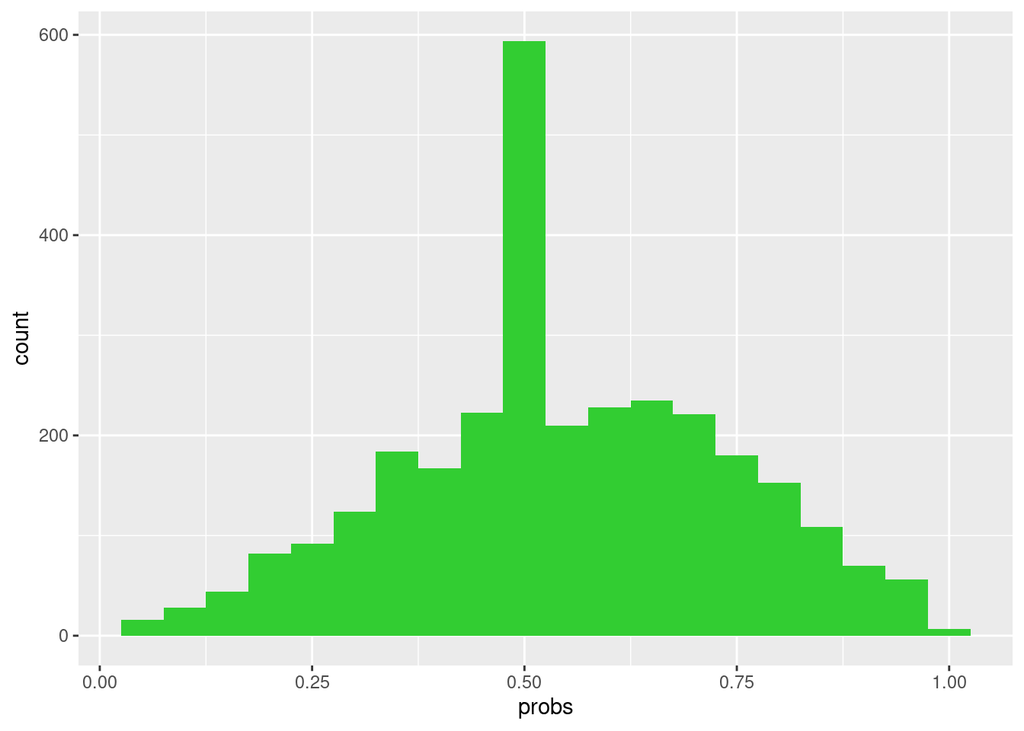

```r
df <- tibble(probs)
df1 <- filter(df,probs>0.5)
df2 <- filter(df,probs<0.5)
df3 <- tibble(log(probs))
ggplot(df, aes(x=probs)) + geom_histogram(binwidth = 0.05,fill= 'limegreen')
```

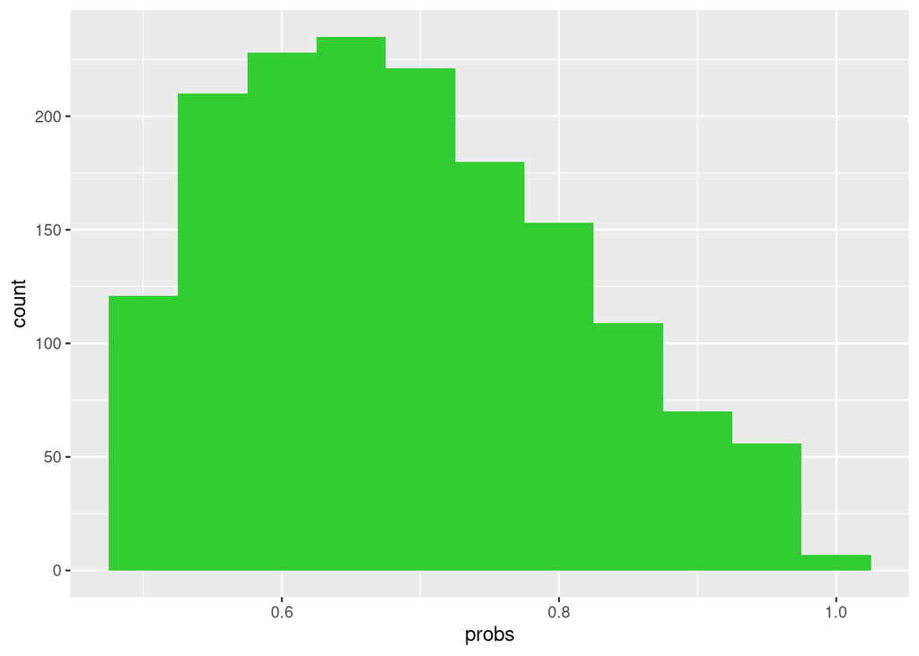

```r
ggplot(df1, aes(x=probs)) +geom_histogram(binwidth = 0.05,fill= 'limegreen')
```

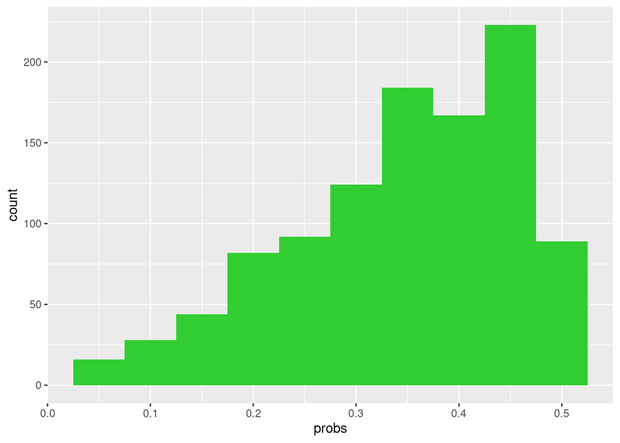

```r
ggplot(df2, aes(x=probs)) + geom_histogram(binwidth = 0.05,fill= 'limegreen')
```

Here we add the line marking the point of a uniformly random guess.

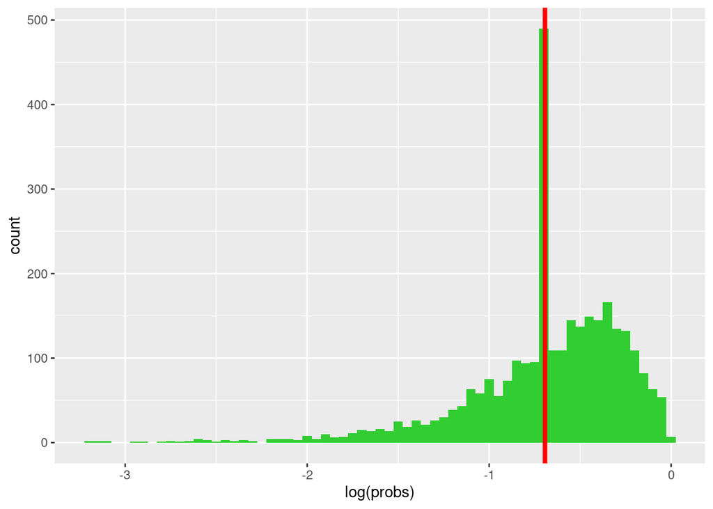

```r
ggplot(df3, aes(x=log(probs))) + geom_histogram(binwidth = 0.05,fill= 'limegreen') + geom_vline(xintercept =  log(0.5), color='red',size=1.5)
```

# Logistic Regression

We shall now move on to fitting a logistic regression to the data and attempt to classify the outcome of the test matches. Let us first call our function that constructs the feature matrix.

```r
features <- feature_matrix_train(my_data)
feature_matrix <- features$matrix
```

Here we have one hot encoded the form of each player on the surface that the match is being played on. We have the age, the form of each player, their head to head percentage and we attach a row of ones that will form the intercept. A 1 in the winner row corresponds to player 1 winning the match, with a -1 for the opposite result.

```r
feature_matrix[,1:5]
```

```
##                     [,1]       [,2]       [,3]       [,4]       [,5]
## Hard           0.5277778  0.2727273  0.5433071  0.3571429  0.3829787
## Clay           0.0000000  0.0000000  0.0000000  0.0000000  0.0000000
## Grass          0.0000000  0.0000000  0.0000000  0.0000000  0.0000000
## Hard           0.4782609  0.4121212  0.4690722  0.5705128  0.3958333
## Clay           0.0000000  0.0000000  0.0000000  0.0000000  0.0000000
## Grass          0.0000000  0.0000000  0.0000000  0.0000000  0.0000000
## p1_age        29.9712526 23.9507187 30.3326489 23.9698836 31.2334018
## p2_age        30.5462012 33.5496235 34.8610541 33.5222450 26.0616016
## p1_form        0.4876543  0.3235294  0.5376344  0.3731343  0.4354839
## p2_form        0.5566038  0.4547945  0.4397394  0.5993377  0.5059761
## p1_headtohead  0.4000000  0.0000000  1.0000000  0.0000000  0.5000000
## intercept      1.0000000  1.0000000  1.0000000  1.0000000  1.0000000
## winner        -1.0000000 -1.0000000  1.0000000 -1.0000000  1.0000000
```

Let us also construct the test matrix.

```r
test_matrix <- feature_matrix_test(my_data)
```

We are now in a position to call our logistic regression function.

```r
# We split the feature matrix into input and output.

x_dat <- feature_matrix[-length(feature_matrix[,1]),]

y_dat <- feature_matrix[length(feature_matrix[,1]),]

# We perform logistic regression.

what <- log_reg(x_dat,y_dat)

x_test <- test_matrix$matrix

f <- t(what)%*%as.matrix(x_test)
pred <- sign(sigma_f(f)-0.5)
```

Let us compute the prediction accuracy. That is the proportion of matches in the test set that we predict correctly.

```r
sum(pred==1)/length(pred)
```

```
## [1] 0.6265365
```

```r
probs <- as.numeric(sigma_f(f))
log_sr1 <- sum(log(probs))/length(probs)
log_sr1
```

```
## [1] -0.9247672
```

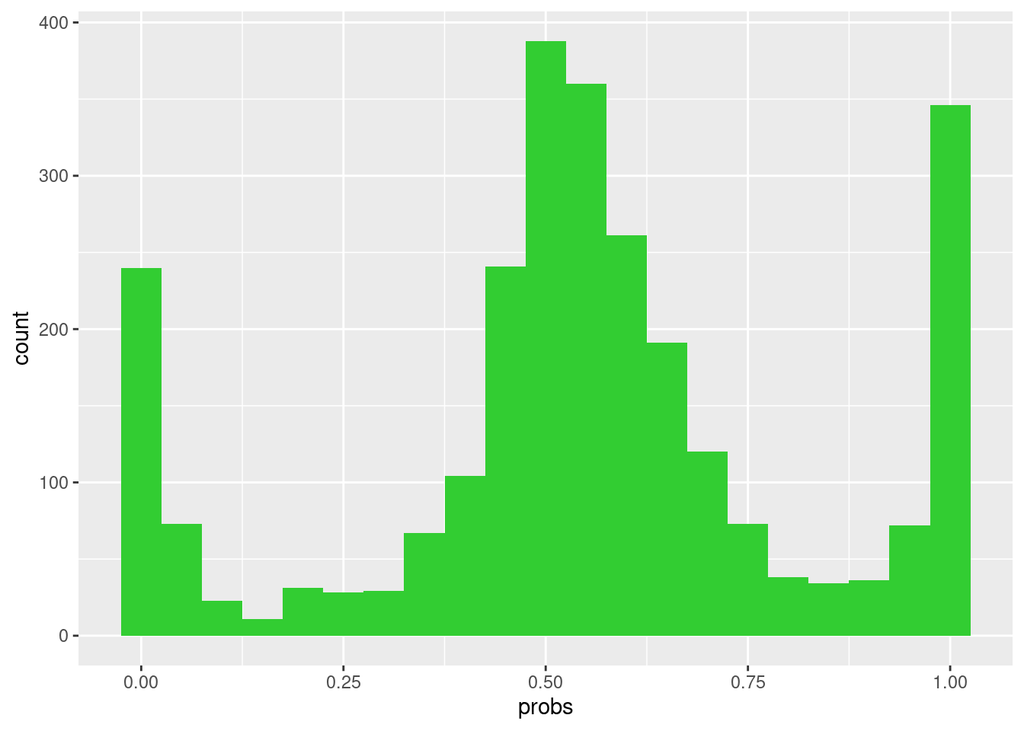

```r
df <- tibble(probs)
df1 <- filter(df,probs>0.5)
df2 <- filter(df,probs<0.5)
df3 <- tibble(log(probs))
ggplot(df, aes(x=probs)) + geom_histogram(binwidth = 0.05,fill= 'limegreen')
```

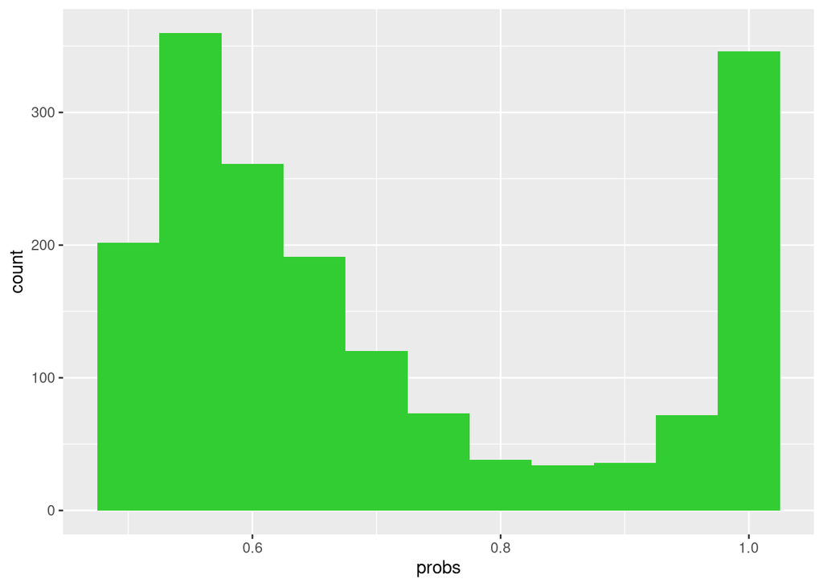

```r
ggplot(df1, aes(x=probs)) +geom_histogram(binwidth = 0.05,fill= 'limegreen')
```

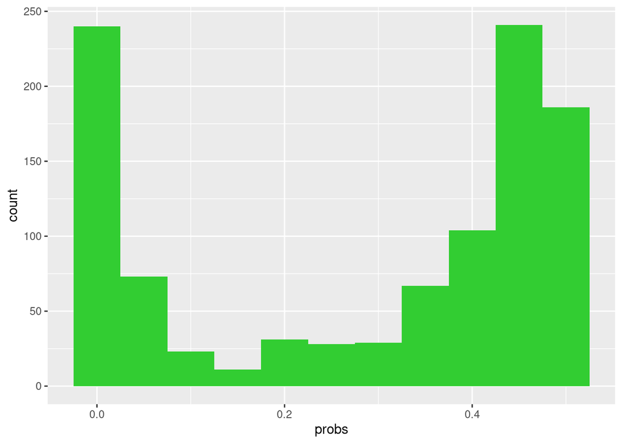

```r
ggplot(df2, aes(x=probs)) + geom_histogram(binwidth = 0.05,fill= 'limegreen')
```

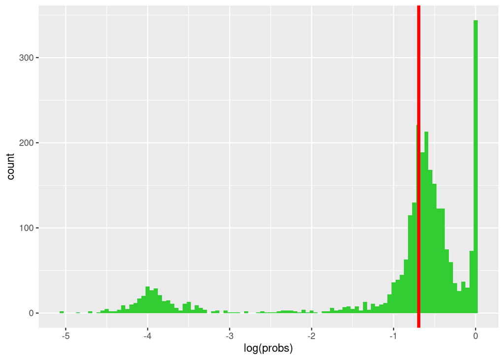

```r
ggplot(df3, aes(x=log(probs))) + geom_histogram(binwidth = 0.05,fill= 'limegreen') + geom_vline(xintercept =  log(0.5), color='red',size=1.5)
```

We observe a cluster of predictions achieving a significantly lower score. This must be affecting the total log score of this model.

Let us look at the magnitudes of the weights to see what features the model finds most important

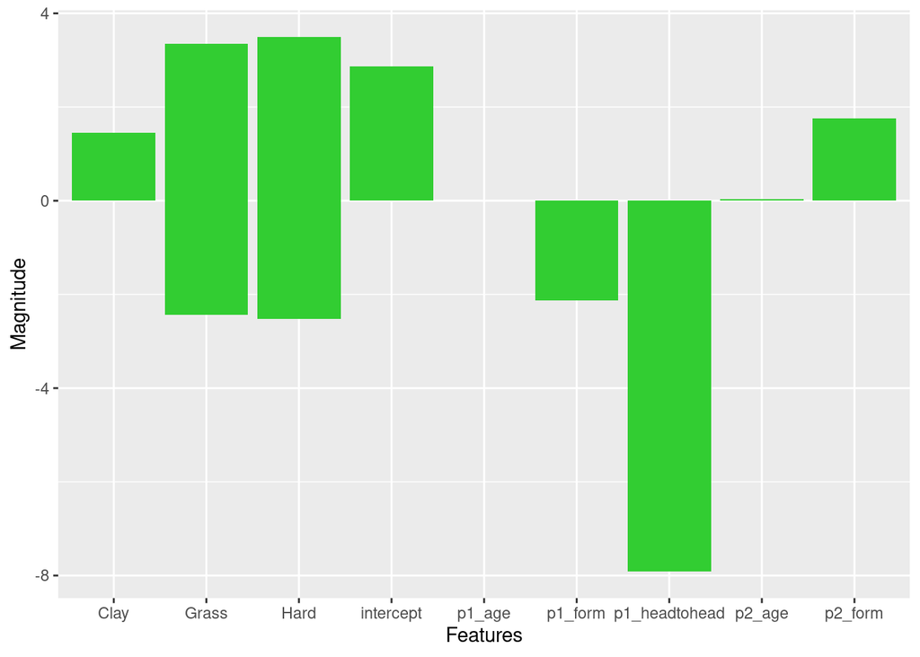

```r
tib <- tibble(Features=rownames(x_dat),Magnitude=(what))
ggplot(data=tib, aes(x=Features, y=Magnitude)) +
  geom_bar(stat="identity",fill= 'limegreen')
```

We observe a significantly larger magnitude of the weight on the `p1_headtohead` feature. This might be the cause of the poorer score.

# Logistic Regression with Bradley-Terry

Let us construct the new feature matrix. To do this we need to extract the Bradley-Terry scores of the players playing in each match.

Now again performing logistic regression.

```r
x_dat <- feature_matrix_BT[-length(feature_matrix_BT[,1]),]

y_dat <- feature_matrix_BT[length(feature_matrix_BT[,1]),]

what <- log_reg(x_dat,y_dat)

x_test <- test_matrix_BT

f <- t(what)%*%as.matrix(x_test)
pred <- sign(sigma_f(f)-0.5)
```

Here again is our prediction accuracy.

```r
sum(pred==1)/length(pred)
```

```
## [1] 0.3991323
```

And the log proper scoring rule.

```r
probs <- as.numeric(sigma_f(f))
log_sr2 <- sum(log(probs))/length(probs)
log_sr2
```

```
## [1] -1.027311
```

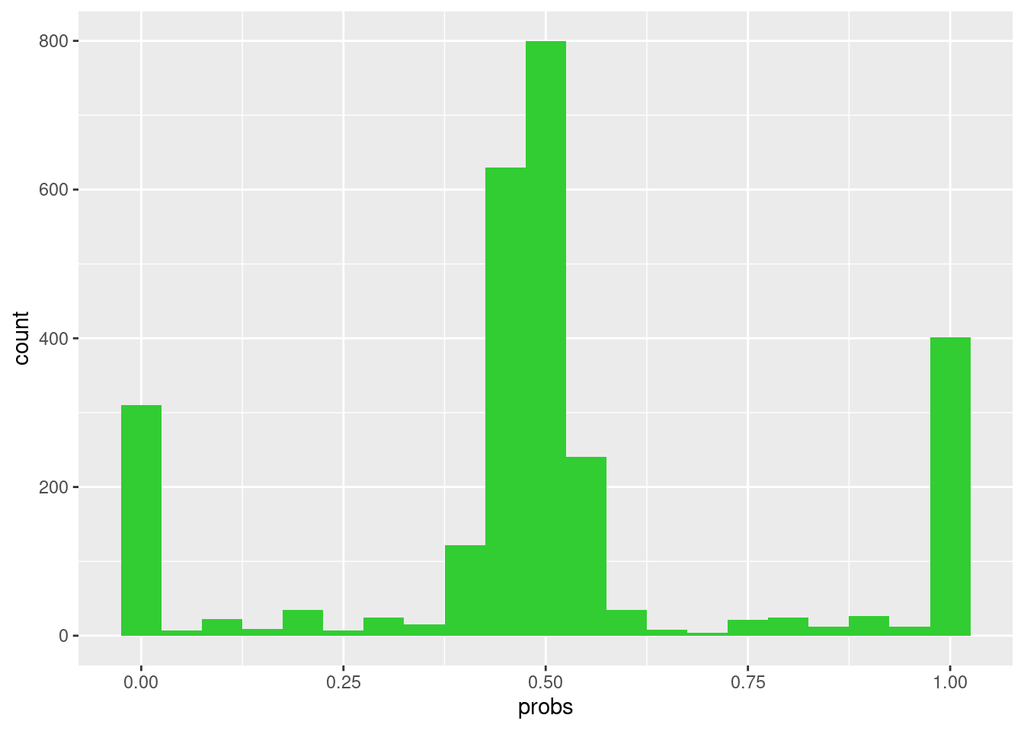

```r
df <- tibble(probs)
df1 <- filter(df,probs>0.5)
df2 <- filter(df,probs<0.5)
df3 <- tibble(log(probs))
ggplot(df, aes(x=probs)) + geom_histogram(binwidth = 0.05,fill= 'limegreen')
```

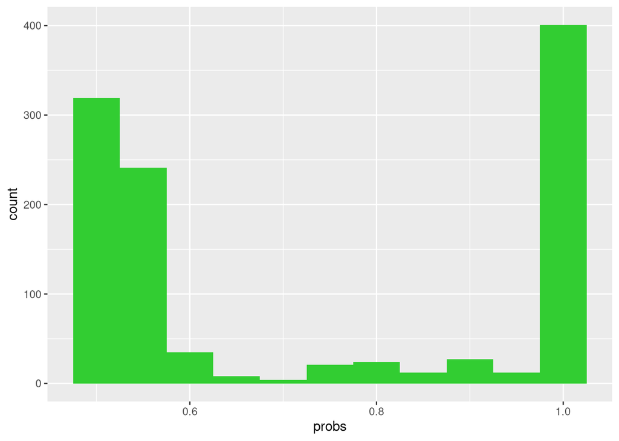

```r
ggplot(df1, aes(x=probs)) +geom_histogram(binwidth = 0.05,fill= 'limegreen')
```

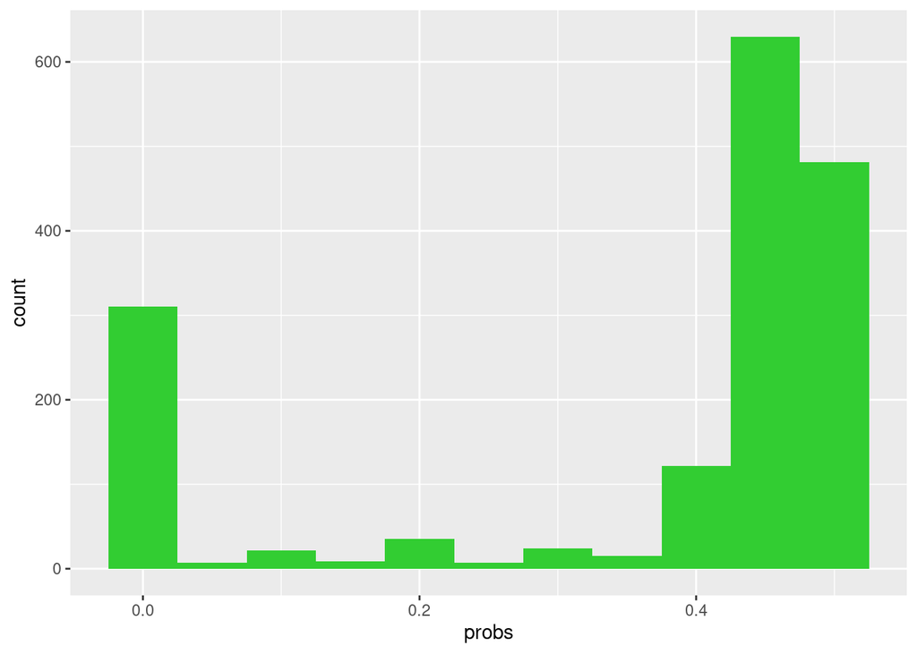

```r
ggplot(df2, aes(x=probs)) + geom_histogram(binwidth = 0.05,fill= 'limegreen')
```

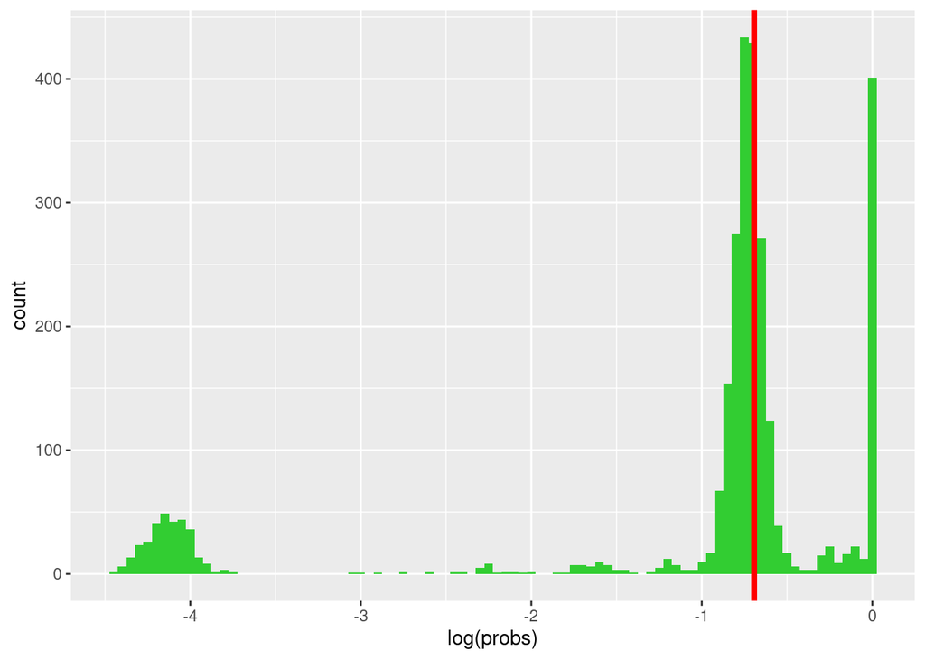

```r
ggplot(df3, aes(x=log(probs))) + geom_histogram(binwidth = 0.05,fill= 'limegreen') + geom_vline(xintercept =  log(0.5), color='red',size=1.5)
```

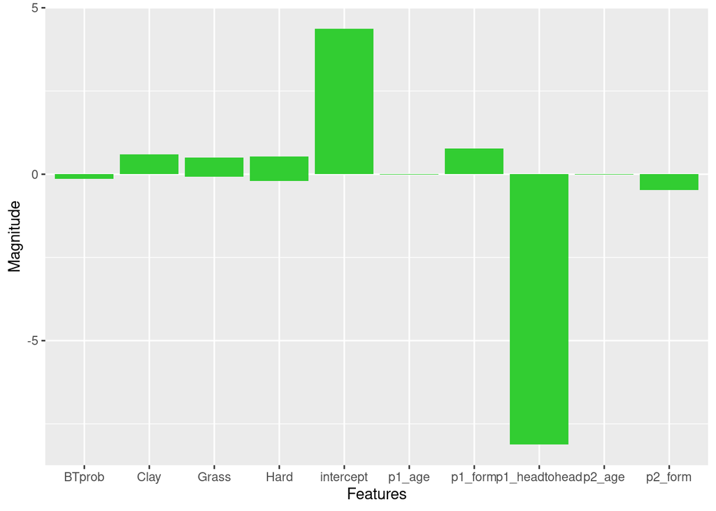

```r
tib <- tibble(Features=rownames(x_dat),Magnitude=(what))
ggplot(data=tib, aes(x=Features, y=Magnitude)) +
  geom_bar(stat="identity",fill= 'limegreen')
```

# Logistic Regression without `p1_headtohead`

Let us precede, without `p1_headtohead` in our model. Repeating each step we did earlier.

```r
features <- feature_matrix_train(my_data, match_date = "2019-01-01",features = c('surface_form', 'age', 'match_form'))
feature_matrix <- features$matrix
```

```r
test_matrix <- feature_matrix_test(my_data,features = c('surface_form', 'age', 'match_form'))
```

```r
x_dat <- feature_matrix[-length(feature_matrix[,1]),]

y_dat <- feature_matrix[length(feature_matrix[,1]),]

what <- log_reg(x_dat,y_dat)

x_test <- test_matrix$matrix

f <- t(what)%*%as.matrix(x_test)
pred <- sign(sigma_f(f)-0.5)
```

Here is our new prediction accuracy.

```r
sum(pred==1)/length(pred)
```

```
## [1] 0.5614606
```

Our new log score:

```r
probs <- as.numeric(sigma_f(f))
log_sr3 <- sum(log(probs))/length(probs)
log_sr3
```

```
## [1] -0.7403464
```

As well as the same plots:

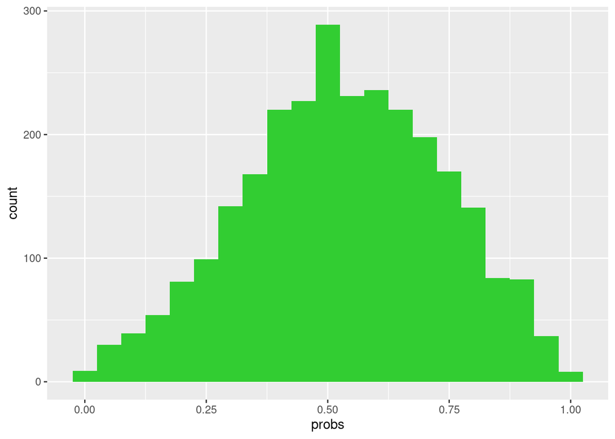

```r
df <- tibble(probs)
df1 <- filter(df,probs>0.5)
df2 <- filter(df,probs<0.5)
df3 <- tibble(log(probs))
ggplot(df, aes(x=probs)) + geom_histogram(binwidth = 0.05,fill= 'limegreen')
```

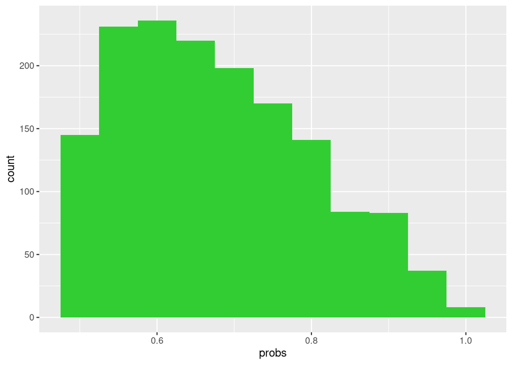

```r
ggplot(df1, aes(x=probs)) +geom_histogram(binwidth = 0.05,fill= 'limegreen')
```

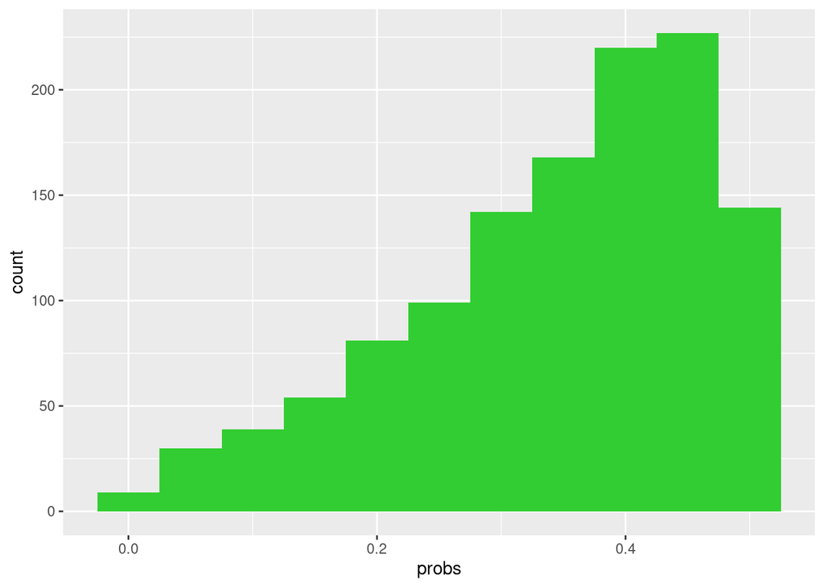

```r
ggplot(df2, aes(x=probs)) + geom_histogram(binwidth = 0.05,fill= 'limegreen')
```

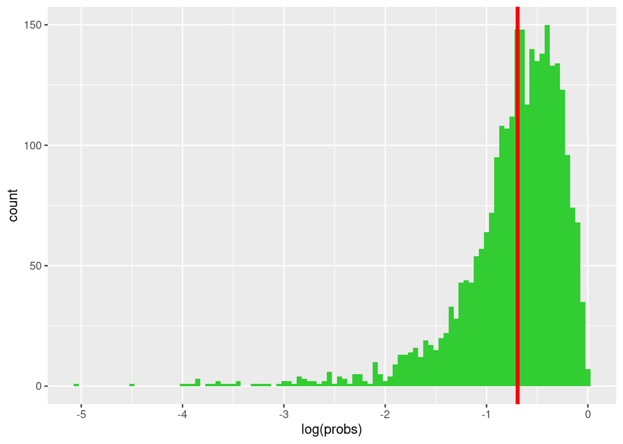

```r
ggplot(df3, aes(x=log(probs))) + geom_histogram(binwidth = 0.05,fill= 'limegreen') + geom_vline(xintercept =  log(0.5), color='red',size=1.5)
```

We no longer have the cluster of poorly predicted probabilities.

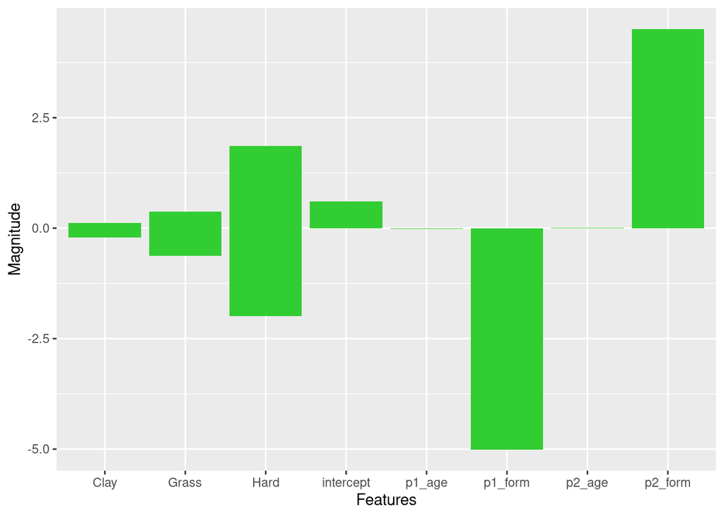

```r
tib <- tibble(Features=rownames(x_dat),Magnitude=(what))
ggplot(data=tib, aes(x=Features, y=Magnitude)) +
  geom_bar(stat="identity",fill= 'limegreen')
```

The model seems to be assigning most importance to the form of the players. Not surprisingly…

# Logistic Regression with Bradley-Terry probabilities but without `p1_headtohead`

Finally, in an attempt to come up with the best model possible, let us add the Bradley-Terry probabilities that we calculated with the EM algorithm. We shall add these as the final feature to our model and we shall continue without the `p1_headtohead` feature.

We need to attach the Bradley-Terry probabilities once again.

Now again performing logistic regression.

```r
x_dat <- feature_matrix_BT[-length(feature_matrix_BT[,1]),]

y_dat <- feature_matrix_BT[length(feature_matrix_BT[,1]),]

what <- log_reg(x_dat,y_dat)

x_test <- test_matrix_BT

f <- t(what)%*%as.matrix(x_test)
pred <- sign(sigma_f(f)-0.5)
```

Here again is our prediction accuracy.

```r
sum(pred==1)/length(pred)
```

```
## [1] 0.643167
```

And the log proper scoring rule.

```r
probs <- as.numeric(sigma_f(f))
log_sr4 <- sum(log(probs))/length(probs)
log_sr4
```

```
## [1] -0.6666666
```

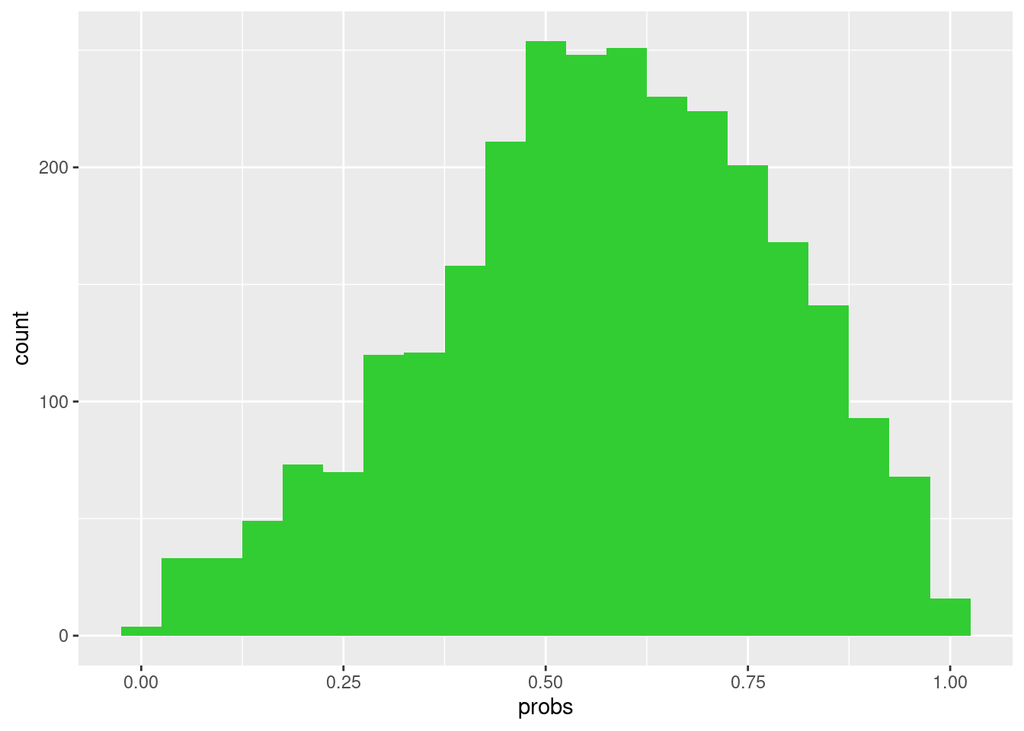

```r
df <- tibble(probs)
df1 <- filter(df,probs>0.5)
df2 <- filter(df,probs<0.5)
df3 <- tibble(log(probs))
ggplot(df, aes(x=probs)) + geom_histogram(binwidth = 0.05,fill= 'limegreen')
```

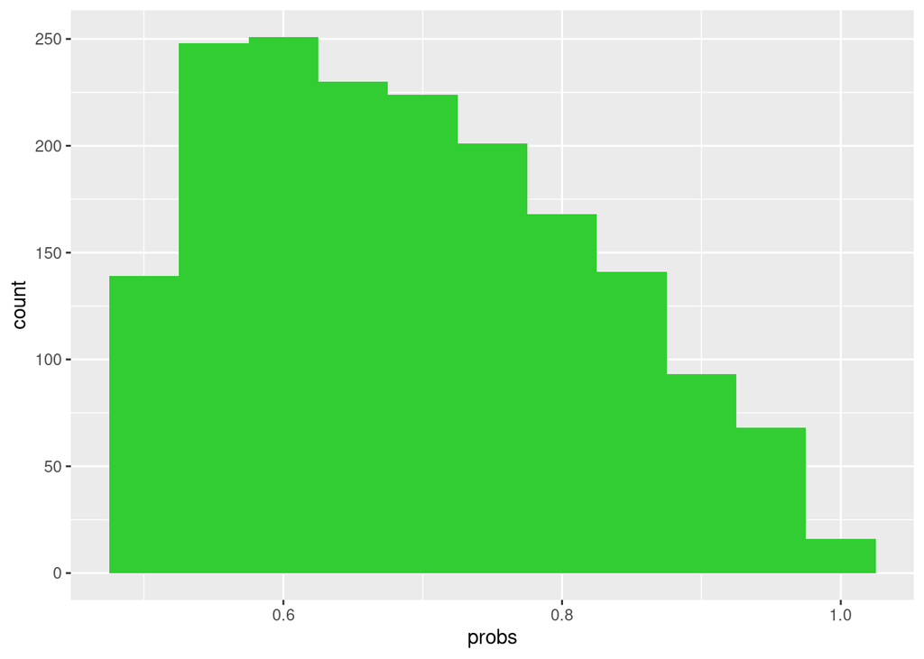

```r
ggplot(df1, aes(x=probs)) +geom_histogram(binwidth = 0.05,fill= 'limegreen')
```

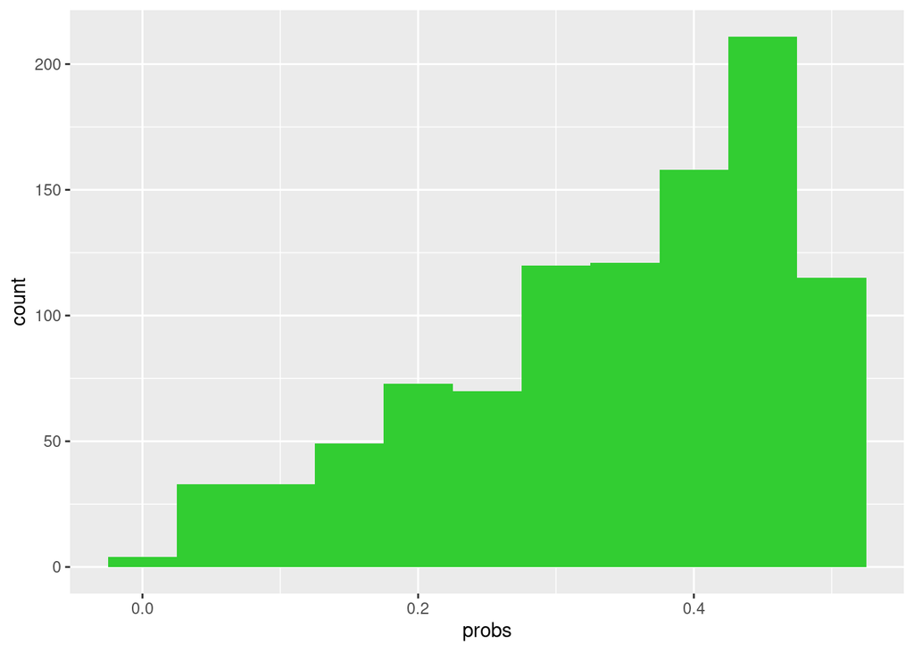

```r
ggplot(df2, aes(x=probs)) + geom_histogram(binwidth = 0.05,fill= 'limegreen')
```

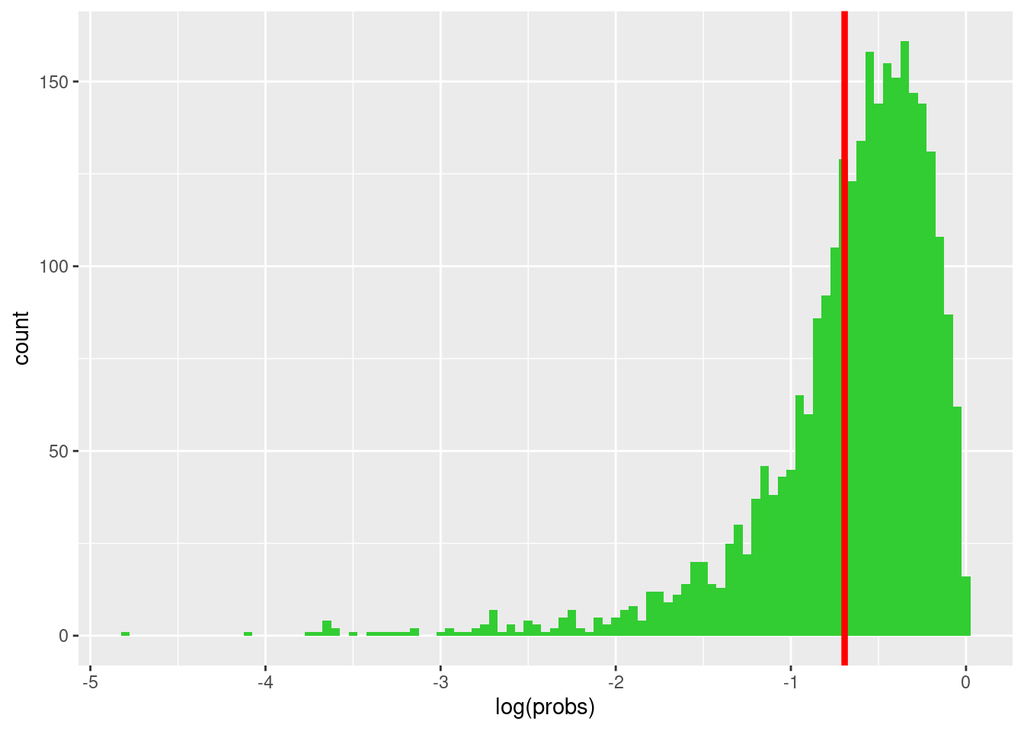

```r
ggplot(df3, aes(x=log(probs))) + geom_histogram(binwidth = 0.05,fill= 'limegreen') + geom_vline(xintercept =  log(0.5), color='red',size=1.5)
```

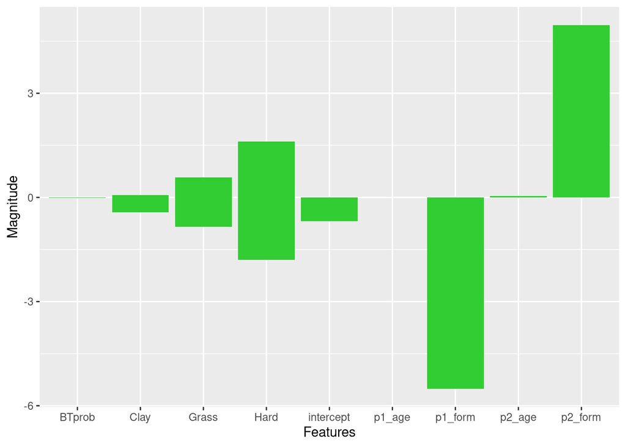

```r
tib <- tibble(Features=rownames(x_dat),Magnitude=(what))
ggplot(data=tib, aes(x=Features, y=Magnitude)) +
  geom_bar(stat="identity",fill= 'limegreen')
```

Finally let us compare the log score of all our models.

```r
table <- data.frame(Model=c('VBT','VLR','LRBT','VLR-H2H','LRBT-H2H'),Log_Score = c(log_sr,log_sr1,log_sr2,log_sr3,log_sr4))
table
```

```
##      Model  Log_Score
## 1      VBT -0.6859029
## 2      VLR -0.9247672
## 3     LRBT -1.0273111
## 4  VLR-H2H -0.7403464
## 5 LRBT-H2H -0.6666666
```